# **Kaggle M5 Forecasting - Accuracy**

#### Using hierarchical sales data from Walmart to forecast daily sales for the next 28 days for 30k+ items

Link for the competition: https://www.kaggle.com/c/m5-forecasting-accuracy

### **Team Member**

Hailey Ling - data import and pre-processing, feature importance and Shapley value  
Jennifer Nguyen - EDA, Partial Dependence and ICE curve  
Laura Le - feature engineering and training XGB model  
Tim Tian - sensitivity analysis

### **Running Note**

We run this notebook on AWS SageMaker using instance **ml.t2.2xlarge** or above, otherwise you'll get Memory Error when creating Dmatrix for xgboost model.

```python
# install xgboost to SageMaker instance
# this installation takes a lot of time
!conda install -y -c conda-forge xgboost
```

```python
# install shapley value package
!pip install shap
```

```python
import warnings
warnings.filterwarnings('ignore')
import numpy as np                   # array, vector, matrix calculations
import pandas as pd                  # DataFrame handling
import dask.dataframe as dd
pd.set_option('display.max_columns', 100)
pd.set_option('display.max_rows', 100)
import matplotlib.pyplot as plt      # plotting
import seaborn as sns
%matplotlib inline                   # enables display of plots in notebook

from sklearn import preprocessing, metrics
import gc
import os

import shap
import xgboost as xgb                # gradient boosting machines (GBMs)
from xgboost import plot_importance, plot_tree
from sklearn.metrics import mean_squared_error, mean_absolute_error

pd.options.display.max_columns = 999 # enable display of all columns in notebook

np.random.seed(12345)                # set random seed for reproducibility
```

## **1. Data Import**

Since we'll work on a very large dataset which contains many numerical columns, we first define a function `reduce_mem_usage()`for reducing memory of storing those columns. We'll use this useful function many times in data pre-processing.

```python
def reduce_mem_usage(df, verbose=True):
    numerics = ['int16', 'int32', 'int64', 'float16', 'float32', 'float64']
    start_mem = df.memory_usage().sum() / 1024**2
    for col in df.columns:
        col_type = df[col].dtypes
        if col_type in numerics:
            c_min = df[col].min()
            c_max = df[col].max()
            if str(col_type)[:3] == 'int':
                if c_min > np.iinfo(np.int8).min and c_max < np.iinfo(np.int8).max:
                    df[col] = df[col].astype(np.int8)
                elif c_min > np.iinfo(np.int16).min and c_max < np.iinfo(np.int16).max:
                    df[col] = df[col].astype(np.int16)
                elif c_min > np.iinfo(np.int32).min and c_max < np.iinfo(np.int32).max:
                    df[col] = df[col].astype(np.int32)
                elif c_min > np.iinfo(np.int64).min and c_max < np.iinfo(np.int64).max:
                    df[col] = df[col].astype(np.int64)
            else:
                if c_min > np.finfo(np.float16).min and c_max < np.finfo(np.float16).max:
                    df[col] = df[col].astype(np.float16)
                elif c_min > np.finfo(np.float32).min and c_max < np.finfo(np.float32).max:
                    df[col] = df[col].astype(np.float32)
                else:
                    df[col] = df[col].astype(np.float64)
    end_mem = df.memory_usage().sum() / 1024**2
    if verbose: print('Mem. usage decreased to {:5.2f} Mb ({:.1f}% reduction)'.format(end_mem, 100 * (start_mem - end_mem) / start_mem))
    return df
```

There're 4 csv files provided by Kaggle. Three of them contain the training and evaluation information, the remaining one regulates the kaggle submission format. We define a function to read those csv data. And this function can help us trace the reading process and check the imported dataframe dimension.

```python
def read_data():
    print('Reading files...')

    calendar = pd.read_csv('https://mlclassteam.s3.amazonaws.com/calendar.csv')
    #use the defined function to reduce memory
    calendar = reduce_mem_usage(calendar)
    print('Calendar has {} rows and {} columns'.format(calendar.shape[0], calendar.shape[1]))

    sell_prices = pd.read_csv('https://mlclassteam.s3.amazonaws.com/sell_prices.csv')
    sell_prices = reduce_mem_usage(sell_prices)
    print('Sell prices has {} rows and {} columns'.format(sell_prices.shape[0], sell_prices.shape[1]))

    sales_train_evaluation = pd.read_csv('https://mlclassteam.s3.amazonaws.com/sales_train_evaluation.csv')
    print('Sales train evaluation has {} rows and {} columns'.format(sales_train_evaluation.shape[0], sales_train_evaluation.shape[1]))

    submission = pd.read_csv('https://mlclassteam.s3.amazonaws.com/sample_submission.csv')

    return calendar, sell_prices, sales_train_evaluation, submission
```

```python
calendar, sell_prices, sales_train_evaluation, submission = read_data()
```

```
Reading files...
Mem. usage decreased to  0.12 Mb (41.9% reduction)
Calendar has 1969 rows and 14 columns
Mem. usage decreased to 130.48 Mb (37.5% reduction)
Sell prices has 6841121 rows and 4 columns
Sales train evaluation has 30490 rows and 1947 columns
```

## **2. Exploratory Data Analysis**

### **2.1 Calendar data set**

```python
#Contains information about the dates on which the products are sold (explanatory vars)
calendar.head(5)
```

|  | date | wm_yr_wk | weekday | wday | month | year | d | event_name_1 | event_type_1 | event_name_2 | event_type_2 | snap_CA | snap_TX | snap_WI |
| --- | --- | --- | --- | --- | --- | --- | --- | --- | --- | --- | --- | --- | --- | --- |
| 0 | 2011-01-29 | 11101 | Saturday | 1 | 1 | 2011 | d_1 | NaN | NaN | NaN | NaN | 0 | 0 | 0 |
| 1 | 2011-01-30 | 11101 | Sunday | 2 | 1 | 2011 | d_2 | NaN | NaN | NaN | NaN | 0 | 0 | 0 |
| 2 | 2011-01-31 | 11101 | Monday | 3 | 1 | 2011 | d_3 | NaN | NaN | NaN | NaN | 0 | 0 | 0 |
| 3 | 2011-02-01 | 11101 | Tuesday | 4 | 2 | 2011 | d_4 | NaN | NaN | NaN | NaN | 1 | 1 | 0 |
| 4 | 2011-02-02 | 11101 | Wednesday | 5 | 2 | 2011 | d_5 | NaN | NaN | NaN | NaN | 1 | 0 | 1 |

Most of the columns here are quite self-explanatory.

- `wm_yr_wk`: the id of the week the date belongs to.
- `wday`: the id of the weekday, starting from Saturday
- `d` : id of the day in this dataset, starting from d_1 *`snap_CA`, `snap_TX`, and `snap_WI` are events that are only observed in either CA, TX or WI state, respectively.

```python
calendar.shape # there are 1969 days(rows) and 14 columns
```

```
(1969, 14)
```

```python
calendar.isnull().sum() #check the number of null values in each column of calendar data frame
```

```
date               0
wm_yr_wk           0
weekday            0
wday               0
month              0
year               0
d                  0
event_name_1    1807
event_type_1    1807
event_name_2    1964
event_type_2    1964
snap_CA            0
snap_TX            0
snap_WI            0
dtype: int64
```

### **2.2 Sales_train_evaluation data set**

```python
sales_train_evaluation.head(5)
```

|  | id | item_id | dept_id | cat_id | store_id | state_id | d_1 | d_2 | d_3 | d_4 | d_5 | d_6 | d_7 | d_8 | d_9 | d_10 | d_11 | d_12 | d_13 | d_14 | d_15 | d_16 | d_17 | d_18 | d_19 | d_20 | d_21 | d_22 | d_23 | … |
| --- | --- | --- | --- | --- | --- | --- | --- | --- | --- | --- | --- | --- | --- | --- | --- | --- | --- | --- | --- | --- | --- | --- | --- | --- | --- | --- | --- | --- | --- | --- |
| 0 | HOBBIES_1_001_CA_1_evaluation | HOBBIES_1_001 | HOBBIES_1 | HOBBIES | CA_1 | CA | 0 | 0 | 0 | 0 | 0 | 0 | 0 | 0 | 0 | 0 | 0 | 0 | 0 | 0 | 0 | 0 | 0 | 0 | 0 | 0 | 0 | 0 | 0 | … |
| 1 | HOBBIES_1_002_CA_1_evaluation | HOBBIES_1_002 | HOBBIES_1 | HOBBIES | CA_1 | CA | 0 | 0 | 0 | 0 | 0 | 0 | 0 | 0 | 0 | 0 | 0 | 0 | 0 | 0 | 0 | 0 | 0 | 0 | 0 | 0 | 0 | 0 | 0 | … |
| 2 | HOBBIES_1_003_CA_1_evaluation | HOBBIES_1_003 | HOBBIES_1 | HOBBIES | CA_1 | CA | 0 | 0 | 0 | 0 | 0 | 0 | 0 | 0 | 0 | 0 | 0 | 0 | 0 | 0 | 0 | 0 | 0 | 0 | 0 | 0 | 0 | 0 | 0 | … |
| 3 | HOBBIES_1_004_CA_1_evaluation | HOBBIES_1_004 | HOBBIES_1 | HOBBIES | CA_1 | CA | 0 | 0 | 0 | 0 | 0 | 0 | 0 | 0 | 0 | 0 | 0 | 0 | 0 | 0 | 0 | 0 | 0 | 0 | 0 | 0 | 0 | 0 | 0 | … |
| 4 | HOBBIES_1_005_CA_1_evaluation | HOBBIES_1_005 | HOBBIES_1 | HOBBIES | CA_1 | CA | 0 | 0 | 0 | 0 | 0 | 0 | 0 | 0 | 0 | 0 | 0 | 0 | 0 | 0 | 0 | 0 | 0 | 0 | 0 | 0 | 0 | 0 | 0 | … |

5 rows × 1947 columns

```python
sales_train_evaluation.shape #there are 30490 different items
```

```
(30490, 1947)
```

In this dataset, we see the following columns:

- `id`: the unique field of this table that includes item_id, store_id and the competition phase (evaluation phase at the submission point of this notebook)
- `item_id`: item identification code
- `dept_id`: department id
- `cat_id`: category_id (a category has many department)
- `store_id`, `state_id`: quite self-explanatory
- d_1 to d_1913: the number of items sold for a specific id within a specific day from d_1 to d_1913. This is the period of time for training data set
- d_1914 to d_1941: the number of items sold for a specific id within a specific day from d_1914 to d_1941. This is the period of time for validation data set (this period is used to score and rank our submission in the public leaderboard)

Not included in this dataset is the 28-day evaluation period (d_1942 to d_1969).

```python
# check to see whether there is any null values
sales_train_evaluation.isnull().sum().sum()
```

```
0
```

Great! There is no missing data in our sales_train_evaluation dataset, which is our main dataset.

Let's check the number of unique id's and unique item_id's in our main dataset.

```python
sales_train_evaluation['id'].nunique()
```

```
30490
```

There are 30490 unique time series of individual item sales data. **Our job is to predict the sales of each series during each day from d_1942 to d_1969.**

```python
sales_train_evaluation['item_id'].nunique()
```

```
3049
```

```python
sales_train_evaluation[['item_id', 'store_id']].groupby('store_id').count()
```

| store_id | item_id |
| --- | --- |
| CA_1 | 3049 |
| CA_2 | 3049 |
| CA_3 | 3049 |
| CA_4 | 3049 |
| TX_1 | 3049 |
| TX_2 | 3049 |
| TX_3 | 3049 |
| WI_1 | 3049 |
| WI_2 | 3049 |
| WI_3 | 3049 |

There are 3049 unique items for each store. Each store sells the same set of items.

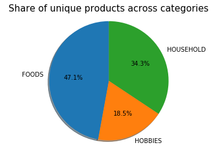

```python
fig1, ax1 = plt.subplots()
ax1.pie(sales_train_evaluation[['item_id','cat_id']].groupby('cat_id').count()[['item_id']], labels=sales_train_evaluation[['item_id','cat_id']].groupby('cat_id').count().index, autopct='%1.1f%%',
        shadow=True, startangle=90)
ax1.axis('equal')  # Equal aspect ratio ensures that pie is drawn as a circle.
plt.title('Share of unique products across categories', size= 15)
plt.show()
```

Food item is the category with the largest number of products (47% of products), followed by Household items.

Now, let's take a look at the distribution of goods in different Departments, the level of classification below Category.

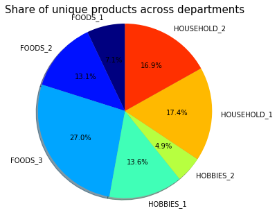

```python
fig1, ax1 = plt.subplots(figsize=(5, 5))

#set the theme of color
theme = plt.get_cmap('jet')
ax1.set_prop_cycle("color", [theme(1. * i / len(sales_train_evaluation[['item_id','dept_id']].groupby('dept_id').count()['item_id']))
                             for i in range(len(sales_train_evaluation[['item_id','dept_id']].groupby('dept_id').count()['item_id']))])

# Draw the pie chart
ax1.pie(sales_train_evaluation[['item_id','dept_id']].groupby('dept_id').count()[['item_id']], labels=sales_train_evaluation[['item_id','dept_id']].groupby('dept_id').count().index, autopct='%1.1f%%',
        shadow=True, startangle=90)
ax1.axis('equal')  # Equal aspect ratio ensures that pie is drawn as a circle.
plt.title('Share of unique products across departments', size= 15)
plt.show()
```

FOODS_3 has the largest number of unique items across all departments, while HOBBIES_2 has the fewest number of unique items.

Next, let's look at some graphs of sales data over the recorded period of time. We picked 3 items representing 3 different goods categories sold at store `WI_2`.

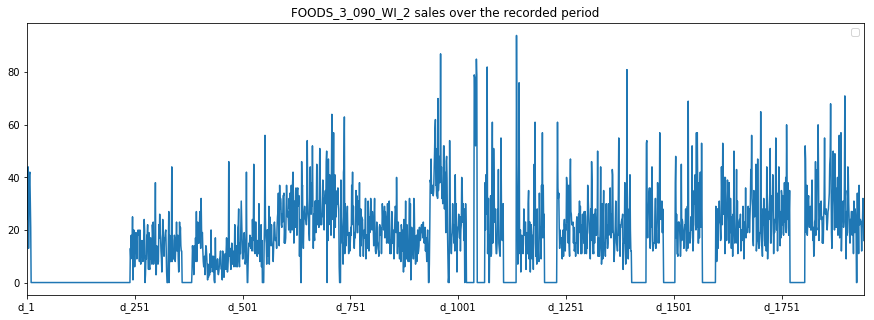

```python
d_cols = [c for c in sales_train_evaluation.columns if 'd_' in c] # sales data columns

# Below we are chaining the following steps in pandas:
# 1. Select the item.
# 2. Set the id as the index, Keep only sales data columns
# 3. Transform so it's a column
# 4. Plot the data
sales_train_evaluation.loc[sales_train_evaluation['id'] == 'FOODS_3_090_WI_2_evaluation'] \
    .set_index('id')[d_cols] \
    .T \
    .plot(figsize=(15, 5),
          title='FOODS_3_090_WI_2 sales over the recorded period')#,color=next(color_cycle))
plt.legend('')
plt.show()
```

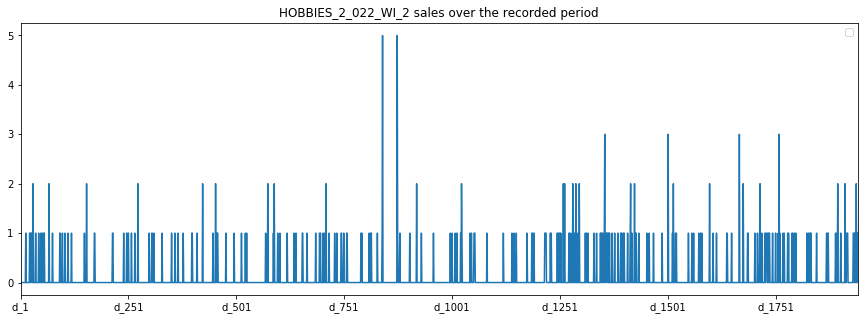

```python
sales_train_evaluation.loc[sales_train_evaluation['id'] == 'HOBBIES_2_022_WI_2_evaluation'] \
    .set_index('id')[d_cols] \
    .T \
    .plot(figsize=(15, 5),
          title='HOBBIES_2_022_WI_2 sales over the recorded period')
plt.legend('')
plt.show()
```

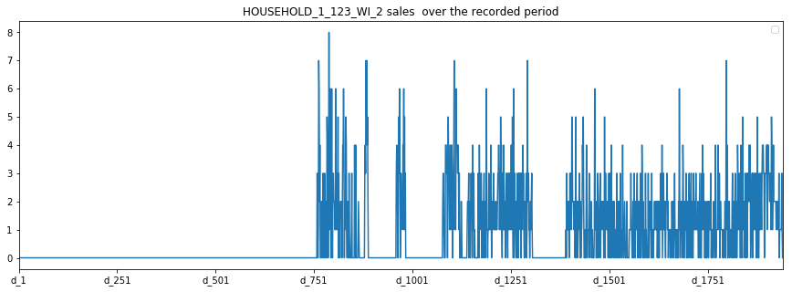

```python
sales_train_evaluation.loc[sales_train_evaluation['id'] == 'HOUSEHOLD_1_123_WI_2_evaluation'] \
    .set_index('id')[d_cols] \
    .T \
    .plot(figsize=(15, 5),
          title='HOUSEHOLD_1_123_WI_2 sales  over the recorded period')#,color=next(color_cycle))
plt.legend('')
plt.show()
```

We see that Food is usually sold in high volume per day and Hobbies and Households are sold in low volume per day. Moreover, there are several items that debuted much later than 2011-01-29 (d_1), resulting in many consecutive days with 0 sales in the beginning, as you can see in the graph of HOUSEHOLD_1_123_WI_2's sales data.

#### **IMPORTANT NOTES ABOUT CONTEST SUBMISSION AND SPLITTING DATASET:**

- Since the competition has released the next 28 days (d_1914 to d_1941), we will just use those labels as our input for our submission under the validation section. In other words, our error for the validation period would be 0. Our job now is to predict d_1942 to d_1969. This is the evaluation section in the submission.
- We will later split the `sales_train_evaluation` dataset into training period and validation(test) period.
- The model with the lowest validation rmse will be used to give prediction for the evaluation period (d_1942 to d_1969).

### **2.3 Sell_prices dataset**

```python
sell_prices.head(5)
```

|  | store_id | item_id | wm_yr_wk | sell_price |
| --- | --- | --- | --- | --- |
| 0 | CA_1 | HOBBIES_1_001 | 11325 | 9.578125 |
| 1 | CA_1 | HOBBIES_1_001 | 11326 | 9.578125 |
| 2 | CA_1 | HOBBIES_1_001 | 11327 | 8.257812 |
| 3 | CA_1 | HOBBIES_1_001 | 11328 | 8.257812 |
| 4 | CA_1 | HOBBIES_1_001 | 11329 | 8.257812 |

```python
sell_prices.isnull().sum().sum() # check for missing values in this dataset
```

```
0
```

There is no mising data here!

### **2.4 Melt and Merge**

We decided to do melt then merge all three of the given datasets (`sales_train_evaluation`, `calendar`, and `sell_prices`) into one single dataset for easy manipulation.

```python
def melt_and_merge(calendar, sell_prices, sales_train_eval, submission, nrows = 30000000, merge = False):

    # melt sales data, get it ready for training - this is our training dataset including d_1 to d_1941
    sales_train_eval = pd.melt(sales_train_eval, id_vars = ['id', 'item_id', 'dept_id', 'cat_id', 'store_id', 'state_id'], var_name = 'day', value_name = 'demand')
    print('Melted sales train evaluation has {} rows and {} columns'.format(sales_train_eval.shape[0], sales_train_eval.shape[1]))

    # reduce memory for sales_train_evaluation
    sales_train_eval = reduce_mem_usage(sales_train_eval)

    test_rows = [row for row in submission['id'] if 'evaluation' in row]
    test = submission[submission['id'].isin(test2_rows)]

    # change column names
    test.columns = ['id', 'd_1942', 'd_1943', 'd_1944', 'd_1945', 'd_1946', 'd_1947', 'd_1948', 'd_1949', 'd_1950', 'd_1951', 'd_1952', 'd_1953', 'd_1954', 'd_1955', 'd_1956', 'd_1957', 'd_1958', 'd_1959',
                    'd_1960', 'd_1961', 'd_1962', 'd_1963', 'd_1964', 'd_1965', 'd_1966', 'd_1967', 'd_1968', 'd_1969']

    # get product table
    product = sales_train_eval[['id', 'item_id', 'dept_id', 'cat_id', 'store_id', 'state_id']].drop_duplicates()

    # merge test to make sure it won't have missing value in some **_id features
    test = test.merge(product, how = 'left', on = 'id')
    test = pd.melt(test, id_vars = ['id', 'item_id', 'dept_id', 'cat_id', 'store_id', 'state_id'], var_name = 'day', value_name = 'demand')


    data = pd.concat([sales_train_eval, test], axis = 0)

    del sales_train_eval, test, product, test_rows

    # get only a sample for fast training
    data = data.loc[nrows:]


    if merge:
        # notebook crash with the entire dataset
        data = pd.merge(data, calendar, how = 'left', left_on = ['day'], right_on = ['d'])
        data.drop(['d', 'day'], inplace = True, axis = 1)

        # get the sell price data
        data = data.merge(sell_prices, on = ['store_id', 'item_id', 'wm_yr_wk'], how = 'left')
        # drop column which is useless or duplicate
        data.drop(['wm_yr_wk', 'weekday','wday'], inplace = True, axis = 1)
        print('Our final dataset to train has {} rows and {} columns'.format(data.shape[0], data.shape[1]))
    else:
        pass

    gc.collect()

    # use to merge and convert encoded id back to original id for submission to kaggle
    id_date = data[['id','date']]

    return data, id_date
```

```python
data, id_date = melt_and_merge(calendar, sell_prices, sales_train_evaluation, submission, merge = True)
```

```
Melted sales train evaluation has 59181090 rows and 8 columns
Mem. usage decreased to 3273.49 Mb (9.4% reduction)
Our final dataset to train has 30034810 rows and 18 columns
```

```python
# check missing values for each column in the dataframe
data.isnull().sum()
```

```
id                     0
item_id                0
dept_id                0
cat_id                 0
store_id               0
state_id               0
demand                 0
date                   0
month                  0
year                   0
event_name_1    27473650
event_type_1    27473650
event_name_2    29943340
event_type_2    29943340
snap_CA                0
snap_TX                0
snap_WI                0
sell_price       1342392
dtype: int64
```

Looks good, only `sell_price` and columns about event contain missing value. This is reasonable. When item is not available at store, the `sell_price` of that day will be missing. And if there's no event on that day, columns about event will also be filled with NA.

```python
data.head()
```

|  | id | item_id | dept_id | cat_id | store_id | state_id | demand | date | month | year | event_name_1 | event_type_1 | event_name_2 | event_type_2 | snap_CA | snap_TX | snap_WI | sell_price |
| --- | --- | --- | --- | --- | --- | --- | --- | --- | --- | --- | --- | --- | --- | --- | --- | --- | --- | --- |
| 0 | HOUSEHOLD_1_331_WI_3_evaluation | HOUSEHOLD_1_331 | HOUSEHOLD_1 | HOUSEHOLD | WI_3 | WI | 0 | 2013-10-08 | 10 | 2013 | NaN | NaN | NaN | NaN | 1 | 0 | 1 | 4.878906 |
| 1 | HOUSEHOLD_1_332_WI_3_evaluation | HOUSEHOLD_1_332 | HOUSEHOLD_1 | HOUSEHOLD | WI_3 | WI | 0 | 2013-10-08 | 10 | 2013 | NaN | NaN | NaN | NaN | 1 | 0 | 1 | NaN |
| 2 | HOUSEHOLD_1_333_WI_3_evaluation | HOUSEHOLD_1_333 | HOUSEHOLD_1 | HOUSEHOLD | WI_3 | WI | 0 | 2013-10-08 | 10 | 2013 | NaN | NaN | NaN | NaN | 1 | 0 | 1 | 2.970703 |
| 3 | HOUSEHOLD_1_334_WI_3_evaluation | HOUSEHOLD_1_334 | HOUSEHOLD_1 | HOUSEHOLD | WI_3 | WI | 11 | 2013-10-08 | 10 | 2013 | NaN | NaN | NaN | NaN | 1 | 0 | 1 | 0.979980 |
| 4 | HOUSEHOLD_1_335_WI_3_evaluation | HOUSEHOLD_1_335 | HOUSEHOLD_1 | HOUSEHOLD | WI_3 | WI | 0 | 2013-10-08 | 10 | 2013 | NaN | NaN | NaN | NaN | 1 | 0 | 1 | 8.968750 |

```python
# check data types for all columns
data.info()
```

```
<class 'pandas.core.frame.DataFrame'>
Int64Index: 30034810 entries, 0 to 30034809
Data columns (total 18 columns):
id              object
item_id         object
dept_id         object
cat_id          object
store_id        object
state_id        object
demand          int64
date            object
month           int8
year            int16
event_name_1    object
event_type_1    object
event_name_2    object
event_type_2    object
snap_CA         int8
snap_TX         int8
snap_WI         int8
sell_price      float16
dtypes: float16(1), int16(1), int64(1), int8(4), object(11)
memory usage: 3.1+ GB
```

```python
# check data skewness for all columns
data.skew() # NaN because of missing values in the data columns
```

```
demand        13.371874
month          0.104841
year          -0.003783
snap_CA        0.737788
snap_TX        0.723435
snap_WI        0.723089
sell_price     2.304829
dtype: float64
```

Since our demand column is highly skewed to the right, we decided to estimate the predictions for future sales/demand according to a poisson distribution. This would eleviate the skewness issue.

Data is prepared well. Before we moving to feature engeering, we delete some original imported dataset for memory saving.

```python
del calendar, sell_prices, sales_train_evaluation
```

## **3. Feature Engineering**

To prepare for the transform step and improve machine learning accuracy since algorithms tend to have a hard time dealing with high cardinality columns, we define target encoding with smoothing function. The `min_samples_leaf` define a threshold where prior and target mean (for a given category value) have the same weight. Below the threshold prior becomes more important and above mean becomes more important. How weight behaves against value counts is controlled by smoothing parameter

```python
def add_noise(series, noise_level):
    return series * (1 + noise_level * np.random.randn(len(series)))

def target_encode(trn_series=None,
                  target=None,
                  min_samples_leaf=100,
                  smoothing=10,
                  noise_level=0.01):

    assert len(trn_series) == len(target)
    temp = pd.concat([trn_series, target], axis=1)

    # Compute target mean
    averages = temp.groupby(by=trn_series.name)[target.name].agg(["mean", "count"])
    # Compute smoothing
    smoothing = 1 / (1 + np.exp(-(averages["count"] - min_samples_leaf) / smoothing))
    # Apply average function to all target data
    prior = target.mean()
    # The bigger the count the less full_avg is taken into account
    averages[target.name] = prior * (1 - smoothing) + averages["mean"] * smoothing
    averages.drop(["mean", "count"], axis=1, inplace=True)

    # Apply averages to trn and tst series
    ft_trn_series = pd.merge(
        trn_series.to_frame(trn_series.name),
        averages.reset_index().rename(columns={'index': target.name, target.name: 'average'}),
        on=trn_series.name,
        how='left')['average'].rename(trn_series.name + '_mean').fillna(prior)
    # pd.merge does not keep the index so restore it
    ft_trn_series.index = trn_series.index

    return add_noise(ft_trn_series, noise_level)
```

We define a transform function to transform features to computer-readable format by combining both label encoding and target encoding. The encoding will be appropriately apply for suitable features to avoid overfitting.

```python
def transform(data):

    nan_features = ['event_name_1', 'event_type_1', 'event_name_2', 'event_type_2']
    for feature in nan_features:
        data[feature].fillna('unknown', inplace = True)

    # we have many missing value in nan_features which is record under the same category 'unknown'
    # It is more appropriate to use target encoding instead of label encording
    cat_label = ['id','event_name_1', 'event_type_1', 'event_name_2', 'event_type_2']
    for feature in cat_label:
        # Encode target labels with value between 0 and n_classes-1
        encoder = preprocessing.LabelEncoder()
        # Fit label encoder and return encoded labels
        data[feature] = encoder.fit_transform(data[feature])

    cat_target = ['item_id', 'dept_id', 'cat_id', 'store_id', 'state_id']
    for feature in cat_target:
        data[feature] = target_encode(data[feature], target=data.demand)

    data = reduce_mem_usage(data)

    return data
```

```python
data = transform(data)
```

```
Mem. usage decreased to 2483.02 Mb (44.7% reduction)
```

Let's create list of features.

```python
def simple_fe(data):

    # rolling demand features
    data['lag_t28'] = data.groupby(['id'])['demand'].transform(lambda x: x.shift(28))
    data['lag_t29'] = data.groupby(['id'])['demand'].transform(lambda x: x.shift(29))
    data['lag_t30'] = data.groupby(['id'])['demand'].transform(lambda x: x.shift(30))

    # compute rolling mean or moving average
    data['rolling_mean_t7'] = data.groupby(['id'])['demand'].transform(lambda x: x.shift(28).rolling(7).mean())
    data['rolling_std_t7'] = data.groupby(['id'])['demand'].transform(lambda x: x.shift(28).rolling(7).std())
    data['rolling_mean_t30'] = data.groupby(['id'])['demand'].transform(lambda x: x.shift(28).rolling(30).mean())
    data['rolling_mean_t90'] = data.groupby(['id'])['demand'].transform(lambda x: x.shift(28).rolling(90).mean())
    data['rolling_mean_t180'] = data.groupby(['id'])['demand'].transform(lambda x: x.shift(28).rolling(180).mean())
    data['rolling_std_t30'] = data.groupby(['id'])['demand'].transform(lambda x: x.shift(28).rolling(30).std())
    data['rolling_skew_t30'] = data.groupby(['id'])['demand'].transform(lambda x: x.shift(28).rolling(30).skew())
    data['rolling_kurt_t30'] = data.groupby(['id'])['demand'].transform(lambda x: x.shift(28).rolling(30).kurt())


    # price features
    data['lag_price_t1'] = data.groupby(['id'])['sell_price'].transform(lambda x: x.shift(7))
    data['price_change_t1'] = (data['lag_price_t1'] - data['sell_price']) / (data['lag_price_t1'])
    data['rolling_price_max_t365'] = data.groupby(['id'])['sell_price'].transform(lambda x: x.shift(1).rolling(365).max())
    data['price_change_t365'] = (data['rolling_price_max_t365'] - data['sell_price']) / (data['rolling_price_max_t365'])
    data['rolling_price_std_t7'] = data.groupby(['id'])['sell_price'].transform(lambda x: x.rolling(7).std())
    data['rolling_price_std_t30'] = data.groupby(['id'])['sell_price'].transform(lambda x: x.rolling(30).std())
    data.drop(['rolling_price_max_t365', 'lag_price_t1'], inplace = True, axis = 1)

    # time features
    data['date'] = pd.to_datetime(data['date'])
    data['week'] = data['date'].dt.week
    data['day'] = data['date'].dt.day
    data['dayofweek'] = data['date'].dt.dayofweek
    data['quarter'] = data['date'].dt.quarter

    # convert 'date' data type from datetime to integer
    data['date'] = pd.to_datetime(data['date']).dt.strftime('%Y%m%d')
    data['date'] = [int(strdt) for strdt in data['date']]

    return data
```

```python
data = reduce_mem_usage(data)
```

[output not shown]

Reduce memory for data set with new features so we can train the data

```python
data = reduce_mem_usage(data)
```

```
Mem. usage decreased to 3342.33 Mb (45.6% reduction)
```